# Monroe

Topics that will be discussed in this summary report for Monroe County are

- Demographic Characteristics
  - Population growth from 1970 to 2020;
  - population density
  - sex, race, and age
  - educational level of the adult population
  - housing characteristics in terms of age of the housing stock and type of tenure
- Economic Characteristics
  - family income, household income, per capita income,
  - poverty status of families;
  - employment classification according to industry;
  - labor force by place of work and commuting patterns;

For more details on the data used, please see the Data Description tab.

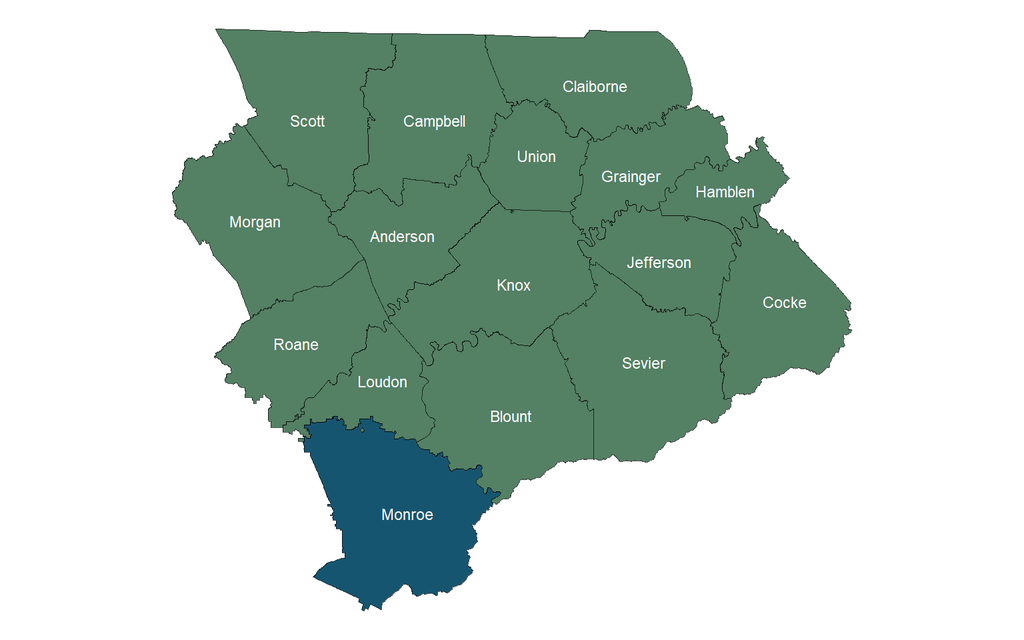

**Population and Growth**

| Place | 1970 | 1980 | 1990 | 2000 | 2010 | 2020 | Change 1970-1980 | Change 1980-1990 | Change 1990-2000 | Change 2000-2010 | Change 2010-2020 |
| --- | --- | --- | --- | --- | --- | --- | --- | --- | --- | --- | --- |
| Monroe County | 23475 | 28700 | 30541 | 38961 | 44519 | 46250 | 5225 | 1841 | 8420 | 5558 | 1731 |
| Madisonville | 2614 | 2884 | 3033 | 3939 | 4577 | 5132 | 270 | 149 | 906 | 638 | 555 |
| Sweetwater | 4340 | 4725 | 5066 | 5586 | 5764 | 6312 | 385 | 341 | 520 | 178 | 548 |
| Tellico Plains |  | 698 | 657 | 859 | 880 | 762 |  | -41 | 202 | 21 | -118 |
| Vonore |  | 528 | 605 | 1162 | 1474 | 1574 |  | 77 | 557 | 312 | 100 |

[interactive chart not shown]

IPUMS NHGIS, University of Minnesota, www.nhgis.org

**Population Density**

| Place | Area | Population Density |
| --- | --- | --- |
| Monroe County | 652.56897435634 | 70.87373414529642 |
| Madisonville | 6.009162262305013 | 854.0291934189595 |
| Sweetwater | 8.849123252913477 | 713.2910029162316 |
| Tellico Plains | 1.952039778066932 | 390.3608976424619 |
| Vonore | 11.75087928253342 | 133.9474231804596 |

[interactive chart not shown]

source: U. S. Census Bureau *Decennial Census: Redistricting Data (PL 94-171)*, 2020, accessed June 2, 2026, http://api.census.gov/data/2020/dec/pl.

**Population Descriptions**

| Place | Year | Race Category | Number of People | Percentage of People |
| --- | --- | --- | --- | --- |
| Monroe County | 2020 | Black | 743 | 0.01237714476095286 |
| Monroe County | 2020 | Other | 3829 | 0.0637847742795269 |
| Monroe County | 2020 | White | 41678 | 0.6942861902382143 |
| Madisonville | 2020 | Black | 151 | 0.002515408962185574 |
| Madisonville | 2020 | Other | 517 | 0.008612360486423455 |
| Madisonville | 2020 | White | 4464 | 0.07436281859070465 |
| Sweetwater | 2020 | Black | 333 | 0.005547226386806597 |
| Sweetwater | 2020 | Other | 655 | 0.0109112110611361 |
| Sweetwater | 2020 | White | 5324 | 0.08868898883891388 |
| Tellico Plains | 2020 | Black | 0 | 0 |

[output cut: 5 more lines]

| Place | Sex | Age Range | Year | Number of People | Percentage of People |
| --- | --- | --- | --- | --- | --- |
| Monroe County | Female | 10 to 14 years | 2020 | 1382 | 0.02286640855091168 |
| Monroe County | Female | 15 to 19 years | 2020 | 1458 | 0.02412389556239452 |
| Monroe County | Female | 20 to 24 years | 2020 | 1184 | 0.01959032396836427 |
| Monroe County | Female | 25 to 29 years | 2020 | 1320 | 0.02184056388364936 |
| Monroe County | Female | 30 to 34 years | 2020 | 1236 | 0.02045070981832622 |
| Monroe County | Female | 35 to 39 years | 2020 | 1346 | 0.02227075680863033 |
| Monroe County | Female | 40 to 44 years | 2020 | 1193 | 0.01973923690393461 |
| Monroe County | Female | 45 to 49 years | 2020 | 1556 | 0.02574539197193819 |
| Monroe County | Female | 5 to 9 years | 2020 | 1248 | 0.02064926039908667 |
| Monroe County | Female | 50 to 54 years | 2020 | 1534 | 0.02538138257387736 |

[output cut: 170 more lines]

[interactive chart not shown]

source: U. S. Census Bureau *Decennial Census: Redistricting Data (PL 94-171)*, 2020, accessed June 2, 2026, http://api.census.gov/data/2020/dec/pl.

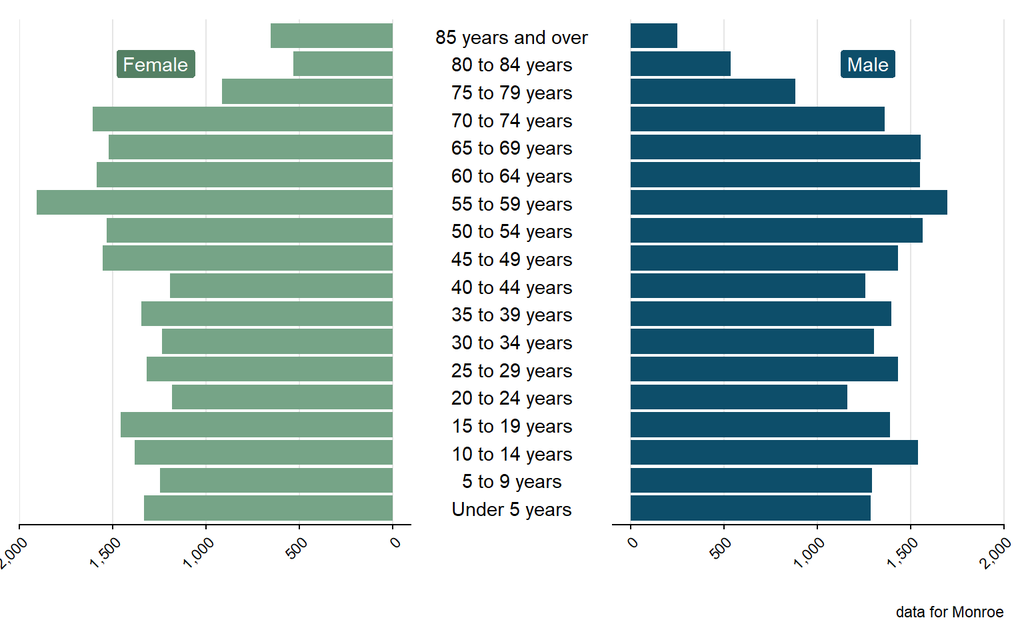

source: U. S. Census Bureau *American Community Survey 5-Year Estimates: Comparison Profiles 5-Year*, 2020, accessed June 2, 2026, http://api.census.gov/data/2020/acs/acs5.

**Education**

| Place | Level of Education | Year | Number of People | Percentage of People |
| --- | --- | --- | --- | --- |
| Monroe County | 9th to 12th Grade, No Diploma | 2010 | 3667 | 0.09378516624040921 |
| Monroe County | Associate's degree | 2010 | 1531 | 0.03915601023017903 |
| Monroe County | Bachelor's degree | 2010 | 2029 | 0.0518925831202046 |
| Monroe County | Graduate or Professional Degree | 2010 | 1132 | 0.02895140664961637 |
| Monroe County | Less Than 9th Grade | 2010 | 4025 | 0.1029411764705882 |
| Monroe County | Some College, No Degree | 2010 | 5085 | 0.1300511508951407 |
| Monroe County | Total | 2010 | 30301 | 0.7749616368286445 |
| Monroe County | 9th to 12th Grade, No Diploma | 2020 | 2326 | 0.05423049124524958 |
| Monroe County | Associate's degree | 2020 | 2580 | 0.06015247954116248 |
| Monroe County | Bachelor's degree | 2020 | 3409 | 0.07948054370380732 |

[output cut: 60 more lines]

[interactive chart not shown]

source: U. S. Census Bureau *American Community Survey 5-Year Estimates: Comparison Profiles 5-Year*, 2020, accessed June 2, 2026, http://api.census.gov/data/2020/acs/acs5.

**Housing Units by Year of Construction**

| Place | Year | 1939 or earlier | 1940-1959 | 1960-1979 | 1980 to 1989 | 1990 to 1999 | 2000 to 2004 | 2005 or later | 2000 to 2009 | 2010 or later | Total |
| --- | --- | --- | --- | --- | --- | --- | --- | --- | --- | --- | --- |
| Monroe County | 2010 | 1246 | 1907 | 5301 | 3366 | 4920 | 2659 | 931 |  |  | 20330 |
| Monroe County | 2020 | 811 | 1525 | 4579 | 3512 | 4527 |  |  | 4768 | 1604 | 21326 |
| Madisonville | 2010 | 95 | 238 | 802 | 309 | 215 | 308 | 115 |  |  | 2082 |
| Sweetwater | 2010 | 428 | 572 | 919 | 308 | 293 | 234 | 34 |  |  | 2788 |
| Tellico Plains | 2010 | 51 | 45 | 97 | 55 | 126 | 11 | 14 |  |  | 399 |
| Vonore | 2010 | 27 | 68 | 92 | 109 | 238 | 102 | 66 |  |  | 702 |
| Madisonville | 2020 | 100 | 194 | 435 | 716 | 313 |  |  | 361 | 130 | 2249 |
| Sweetwater | 2020 | 178 | 416 | 838 | 417 | 333 |  |  | 319 | 171 | 2672 |
| Tellico Plains | 2020 | 43 | 99 | 134 | 48 | 95 |  |  | 119 | 23 | 561 |
| Vonore | 2020 | 24 | 100 | 177 | 177 | 235 |  |  | 215 | 19 | 947 |

[interactive chart not shown]

source: U. S. Census Bureau *Decennial Census: Redistricting Data (PL 94-171)*, 2020, accessed June 2, 2026, http://api.census.gov/data/2020/dec/pl.

**Housing Units by Type of Tenure**

| Place | Year | Own | Rent | Total |
| --- | --- | --- | --- | --- |
| Monroe County | 2010 | 13078 | 4468 | 17546 |
| Monroe County | 2020 | 13800 | 4839 | 18639 |
| Madisonville | 2010 | 1050 | 798 | 1848 |
| Sweetwater | 2010 | 1510 | 922 | 2432 |
| Tellico Plains | 2010 | 197 | 167 | 364 |
| Vonore | 2010 | 396 | 228 | 624 |
| Madisonville | 2020 | 1249 | 746 | 1995 |
| Sweetwater | 2020 | 1333 | 1102 | 2435 |
| Tellico Plains | 2020 | 299 | 168 | 467 |
| Vonore | 2020 | 542 | 351 | 893 |

[interactive chart not shown]

source: U. S. Census Bureau *Decennial Census: Redistricting Data (PL 94-171)*, 2020, accessed June 2, 2026, http://api.census.gov/data/2020/dec/pl.

**Income Comparison**

| Place | Year | Median Family Income | Median Household Income | Per Capita Income |
| --- | --- | --- | --- | --- |
| Monroe County | 2020 | 57539 | 45576 | 25179 |
| Madisonville | 2020 | 60211 | 45188 | 36467 |
| Sweetwater | 2020 | 44670 | 38510 | 22866 |
| Tellico Plains | 2020 | 40179 | 31827 | 16511 |
| Vonore | 2020 | 50250 | 45096 | 28505 |

[interactive chart not shown]

source: U. S. Census Bureau *Decennial Census: Redistricting Data (PL 94-171)*, 2020, accessed June 2, 2026, http://api.census.gov/data/2020/dec/pl.

**Povery Status**

| Place | Year | Above Poverty | Below Poverty |
| --- | --- | --- | --- |
| Monroe County | 2020 | 11337 | 1657 |
| Madisonville | 2020 | 1005 | 139 |
| Sweetwater | 2020 | 1459 | 238 |
| Tellico Plains | 2020 | 239 | 109 |
| Vonore | 2020 | 595 | 50 |

[interactive chart not shown]

source: U. S. Census Bureau *American Community Survey 5-Year Estimates: Comparison Profiles 5-Year*, 2020, accessed June 2, 2026, http://api.census.gov/data/2020/acs/acs5.

**Poverty Status by Family Type**

| Place | Poverty Status | Family Type | Number of Families | Year | Percentage of Families |
| --- | --- | --- | --- | --- | --- |
| Monroe County | Above Poverty | All Families | 11337 | 2020 | 0.6736985975754695 |
| Monroe County | Above Poverty | Female Householder | 1379 | 2020 | 0.0819467554076539 |
| Monroe County | Above Poverty | Female Householder with related children | 758 | 2020 | 0.04504397432850012 |
| Monroe County | Below Poverty | All Families | 1657 | 2020 | 0.09846684097932018 |
| Monroe County | Below Poverty | Female Householder | 663 | 2020 | 0.03939862134537675 |
| Monroe County | Below Poverty | Female Householder with related children | 590 | 2020 | 0.03506061326360827 |
| Madisonville | Above Poverty | All Families | 1005 | 2020 | 0.05972189208462087 |
| Madisonville | Above Poverty | Female Householder | 132 | 2020 | 0.007844069408129309 |
| Madisonville | Above Poverty | Female Householder with related children | 60 | 2020 | 0.003565486094604231 |
| Madisonville | Below Poverty | All Families | 139 | 2020 | 0.008260042785833135 |

[output cut: 20 more lines]

[interactive chart not shown]

source: U. S. Census Bureau *American Community Survey 5-Year Estimates: Comparison Profiles 5-Year*, 2020, accessed June 2, 2026, http://api.census.gov/data/2020/acs/acs5.

**Employment by Industry**

| Place | Industry | Year | Number of Jobs | Percentage of Jobs |
| --- | --- | --- | --- | --- |
| Madisonville | Construction | 2010 | 147 | 0.07976125881714596 |
| Madisonville | Construction | 2020 | 89 | 0.004955456570155902 |
| Madisonville | Educational Services, And Health Care And Social Assistance | 2010 | 340 | 0.1844818231144872 |
| Madisonville | Educational Services, And Health Care And Social Assistance | 2020 | 411 | 0.02288418708240535 |
| Madisonville | Manufacturing | 2010 | 431 | 0.2338578404774824 |
| Madisonville | Manufacturing | 2020 | 475 | 0.02644766146993318 |
| Madisonville | Other Industries | 2010 | 718 | 0.3895822029300055 |
| Madisonville | Other Industries | 2020 | 534 | 0.02973273942093541 |
| Madisonville | Retail Trade | 2010 | 167 | 0.09061313076505698 |
| Madisonville | Retail Trade | 2020 | 414 | 0.02305122494432071 |

[output cut: 50 more lines]

[interactive chart not shown]

source: U. S. Census Bureau *American Community Survey 5-Year Estimates: Comparison Profiles 5-Year*, 2020, accessed June 2, 2026, http://api.census.gov/data/2020/acs/acs5.

**Employment by Industry (Historical)**

| Place | Year | Industry | Number of Jobs | Percentage of Jobs |
| --- | --- | --- | --- | --- |
| Madisonville | 2010 | Agriculture, Forestry, Fishing And Hunting, And Mining | 0 | 0 |
| Madisonville | 2010 | Construction | 147 | 0.006504136985089155 |
| Madisonville | 2010 | Manufacturing | 431 | 0.01906995265696208 |
| Madisonville | 2010 | Other | 31 | 0.001371620724746693 |
| Madisonville | 2010 | Professional Services | 687 | 0.03039688509357993 |
| Madisonville | 2010 | Public Administration | 122 | 0.005397991239325693 |
| Madisonville | 2010 | Trade, Finance, Insurance &amp; Real Estate | 425 | 0.01880447767797885 |
| Madisonville | 2020 | Agriculture, Forestry, Fishing And Hunting, And Mining | 0 | 0 |
| Madisonville | 2020 | Construction | 89 | 0.003754007086215623 |
| Madisonville | 2020 | Manufacturing | 475 | 0.02003543107811709 |

[output cut: 60 more lines]

**Labor Force by Place of Work**

| Place | Year | Work Out Of State | Work Out of County of Residence | Work in County of Residence |
| --- | --- | --- | --- | --- |
| Monroe County | 2020 | 327 | 6265 | 10915 |
| Madisonville | 2020 | 29 | 507 | 1592 |
| Sweetwater | 2020 | 32 | 826 | 1446 |
| Tellico Plains | 2020 | 8 | 50 | 335 |
| Vonore | 2020 | 11 | 217 | 583 |

[interactive chart not shown]

source: U. S. Census Bureau *American Community Survey 5-Year Estimates: Comparison Profiles 5-Year*, 2020, accessed June 2, 2026, http://api.census.gov/data/2020/acs/acs5.

**Commuting Patterns**

| Home County | Year | Number of Jobs | Percentage of Jobs |
| --- | --- | --- | --- |
| Monroe | 2020 | 6679 | 0.2662228954081632 |
| Monroe | 2010 | 6045 | 0.2409518494897959 |
| McMinn | 2020 | 1565 | 0.06238042091836735 |
| Loudon | 2020 | 1268 | 0.05054209183673469 |
| McMinn | 2010 | 1177 | 0.04691485969387755 |
| Blount | 2020 | 1062 | 0.04233099489795918 |
| Knox | 2020 | 805 | 0.03208705357142857 |
| Loudon | 2010 | 802 | 0.03196747448979592 |
| Blount | 2010 | 721 | 0.02873883928571428 |
| Knox | 2010 | 709 | 0.02826052295918367 |

[output cut: 3 more lines]

| Work County | Year | Number of Jobs | Percentage of Jobs |
| --- | --- | --- | --- |
| Monroe | 2020 | 6679 | 0.2662228954081632 |
| Monroe | 2010 | 6045 | 0.2409518494897959 |
| Knox | 2020 | 2022 | 0.08059630102040816 |
| McMinn | 2020 | 1801 | 0.07178730867346939 |
| Loudon | 2020 | 1660 | 0.06616709183673469 |
| Knox | 2010 | 1607 | 0.06405452806122448 |
| Loudon | 2010 | 1482 | 0.05907206632653061 |
| McMinn | 2010 | 1203 | 0.04795121173469388 |
| Blount | 2020 | 1102 | 0.04392538265306122 |
| Blount | 2010 | 1020 | 0.04065688775510204 |

[output cut: 3 more lines]

[interactive chart not shown]

source: U. S. Census Bureau *Tn_od_main_JT00_2020*, LEHD Origin-Destination Employment Statistics, 8.3, 2020, accessed June 2, 2026, https://lehd.ces.census.gov/data/lodes/.

## References

Bureau, U. S. Census. *American Community Survey 5-Year Estimates: Comparison Profiles 5-Year*. 2020. Accessed June 2, 2026. http://api.census.gov/data/2020/acs/acs5.

Bureau, U. S. Census. *Decennial Census: Redistricting Data (PL 94-171)*. 2020. Accessed June 2, 2026. http://api.census.gov/data/2020/dec/pl.

Bureau, U. S. Census. *Tn_od_main_JT00_2020*. LEHD Origin-Destination Employment Statistics, 8.3. 2020. Accessed June 2, 2026. https://lehd.ces.census.gov/data/lodes/.